# Risk Factor Analysis

## Outcome Variable

**Outcome Variable:** haz

## Predictor Variables

**Intervention Variable:** predfeed36

**Adjustment Set:**

unadjusted

## Stratifying Variables

The analysis was stratified on these variable(s):

- agecat
- studyid
- country

## Data Summary

| agecat | studyid | country | predfeed36 | n_cell | n |
| --- | --- | --- | --- | --- | --- |
| Birth | ki0047075b-MAL-ED | BANGLADESH | 1 | 72 | 221 |
| Birth | ki0047075b-MAL-ED | BANGLADESH | 0 | 149 | 221 |
| Birth | ki0047075b-MAL-ED | BRAZIL | 1 | 8 | 65 |
| Birth | ki0047075b-MAL-ED | BRAZIL | 0 | 57 | 65 |
| Birth | ki0047075b-MAL-ED | INDIA | 1 | 4 | 42 |
| Birth | ki0047075b-MAL-ED | INDIA | 0 | 38 | 42 |
| Birth | ki0047075b-MAL-ED | NEPAL | 1 | 1 | 26 |
| Birth | ki0047075b-MAL-ED | NEPAL | 0 | 25 | 26 |
| Birth | ki0047075b-MAL-ED | PERU | 1 | 58 | 223 |
| Birth | ki0047075b-MAL-ED | PERU | 0 | 165 | 223 |
| Birth | ki0047075b-MAL-ED | SOUTH AFRICA | 1 | 2 | 105 |
| Birth | ki0047075b-MAL-ED | SOUTH AFRICA | 0 | 103 | 105 |
| Birth | ki0047075b-MAL-ED | TANZANIA, UNITED REPUBLIC OF | 1 | 0 | 119 |
| Birth | ki0047075b-MAL-ED | TANZANIA, UNITED REPUBLIC OF | 0 | 119 | 119 |
| Birth | ki1000109-EE | PAKISTAN | 1 | 3 | 7 |
| Birth | ki1000109-EE | PAKISTAN | 0 | 4 | 7 |
| Birth | ki1113344-GMS-Nepal | NEPAL | 1 | 422 | 526 |
| Birth | ki1113344-GMS-Nepal | NEPAL | 0 | 104 | 526 |
| Birth | kiGH5241-JiVitA-3 | BANGLADESH | 1 | 8334 | 10681 |
| Birth | kiGH5241-JiVitA-3 | BANGLADESH | 0 | 2347 | 10681 |
| Birth | kiGH5241-JiVitA-4 | BANGLADESH | 1 | 1999 | 2517 |
| Birth | kiGH5241-JiVitA-4 | BANGLADESH | 0 | 518 | 2517 |
| 6 months | ki0047075b-MAL-ED | BANGLADESH | 1 | 81 | 240 |
| 6 months | ki0047075b-MAL-ED | BANGLADESH | 0 | 159 | 240 |
| 6 months | ki0047075b-MAL-ED | BRAZIL | 1 | 25 | 209 |
| 6 months | ki0047075b-MAL-ED | BRAZIL | 0 | 184 | 209 |
| 6 months | ki0047075b-MAL-ED | INDIA | 1 | 17 | 233 |
| 6 months | ki0047075b-MAL-ED | INDIA | 0 | 216 | 233 |
| 6 months | ki0047075b-MAL-ED | NEPAL | 1 | 8 | 235 |
| 6 months | ki0047075b-MAL-ED | NEPAL | 0 | 227 | 235 |
| 6 months | ki0047075b-MAL-ED | PERU | 1 | 72 | 272 |
| 6 months | ki0047075b-MAL-ED | PERU | 0 | 200 | 272 |
| 6 months | ki0047075b-MAL-ED | SOUTH AFRICA | 1 | 3 | 250 |
| 6 months | ki0047075b-MAL-ED | SOUTH AFRICA | 0 | 247 | 250 |
| 6 months | ki0047075b-MAL-ED | TANZANIA, UNITED REPUBLIC OF | 1 | 5 | 243 |
| 6 months | ki0047075b-MAL-ED | TANZANIA, UNITED REPUBLIC OF | 0 | 238 | 243 |
| 6 months | ki1000109-EE | PAKISTAN | 1 | 4 | 9 |
| 6 months | ki1000109-EE | PAKISTAN | 0 | 5 | 9 |
| 6 months | ki1000304b-SAS-FoodSuppl | INDIA | 1 | 0 | 168 |
| 6 months | ki1000304b-SAS-FoodSuppl | INDIA | 0 | 168 | 168 |
| 6 months | ki1113344-GMS-Nepal | NEPAL | 1 | 422 | 527 |
| 6 months | ki1113344-GMS-Nepal | NEPAL | 0 | 105 | 527 |
| 6 months | ki1148112-LCNI-5 | MALAWI | 1 | 47 | 272 |
| 6 months | ki1148112-LCNI-5 | MALAWI | 0 | 225 | 272 |
| 6 months | kiGH5241-JiVitA-3 | BANGLADESH | 1 | 6593 | 8552 |
| 6 months | kiGH5241-JiVitA-3 | BANGLADESH | 0 | 1959 | 8552 |
| 6 months | kiGH5241-JiVitA-4 | BANGLADESH | 1 | 3253 | 4185 |
| 6 months | kiGH5241-JiVitA-4 | BANGLADESH | 0 | 932 | 4185 |
| 24 months | ki0047075b-MAL-ED | BANGLADESH | 1 | 69 | 212 |
| 24 months | ki0047075b-MAL-ED | BANGLADESH | 0 | 143 | 212 |
| 24 months | ki0047075b-MAL-ED | BRAZIL | 1 | 20 | 169 |
| 24 months | ki0047075b-MAL-ED | BRAZIL | 0 | 149 | 169 |
| 24 months | ki0047075b-MAL-ED | INDIA | 1 | 17 | 224 |
| 24 months | ki0047075b-MAL-ED | INDIA | 0 | 207 | 224 |
| 24 months | ki0047075b-MAL-ED | NEPAL | 1 | 8 | 227 |
| 24 months | ki0047075b-MAL-ED | NEPAL | 0 | 219 | 227 |
| 24 months | ki0047075b-MAL-ED | PERU | 1 | 53 | 201 |
| 24 months | ki0047075b-MAL-ED | PERU | 0 | 148 | 201 |
| 24 months | ki0047075b-MAL-ED | SOUTH AFRICA | 1 | 3 | 235 |
| 24 months | ki0047075b-MAL-ED | SOUTH AFRICA | 0 | 232 | 235 |
| 24 months | ki0047075b-MAL-ED | TANZANIA, UNITED REPUBLIC OF | 1 | 4 | 213 |
| 24 months | ki0047075b-MAL-ED | TANZANIA, UNITED REPUBLIC OF | 0 | 209 | 213 |
| 24 months | ki1000109-EE | PAKISTAN | 1 | 0 | 3 |
| 24 months | ki1000109-EE | PAKISTAN | 0 | 3 | 3 |
| 24 months | ki1113344-GMS-Nepal | NEPAL | 1 | 363 | 446 |
| 24 months | ki1113344-GMS-Nepal | NEPAL | 0 | 83 | 446 |
| 24 months | ki1148112-LCNI-5 | MALAWI | 1 | 34 | 189 |
| 24 months | ki1148112-LCNI-5 | MALAWI | 0 | 155 | 189 |
| 24 months | kiGH5241-JiVitA-3 | BANGLADESH | 1 | 3334 | 4334 |
| 24 months | kiGH5241-JiVitA-3 | BANGLADESH | 0 | 1000 | 4334 |
| 24 months | kiGH5241-JiVitA-4 | BANGLADESH | 1 | 3157 | 4049 |
| 24 months | kiGH5241-JiVitA-4 | BANGLADESH | 0 | 892 | 4049 |

The following strata were considered:

- agecat: 24 months, studyid: ki0047075b-MAL-ED, country: BANGLADESH
- agecat: 24 months, studyid: ki0047075b-MAL-ED, country: BRAZIL
- agecat: 24 months, studyid: ki0047075b-MAL-ED, country: INDIA
- agecat: 24 months, studyid: ki0047075b-MAL-ED, country: NEPAL
- agecat: 24 months, studyid: ki0047075b-MAL-ED, country: PERU
- agecat: 24 months, studyid: ki0047075b-MAL-ED, country: SOUTH AFRICA
- agecat: 24 months, studyid: ki0047075b-MAL-ED, country: TANZANIA, UNITED REPUBLIC OF
- agecat: 24 months, studyid: ki1000109-EE, country: PAKISTAN
- agecat: 24 months, studyid: ki1113344-GMS-Nepal, country: NEPAL
- agecat: 24 months, studyid: ki1148112-LCNI-5, country: MALAWI
- agecat: 24 months, studyid: kiGH5241-JiVitA-3, country: BANGLADESH
- agecat: 24 months, studyid: kiGH5241-JiVitA-4, country: BANGLADESH
- agecat: 6 months, studyid: ki0047075b-MAL-ED, country: BANGLADESH
- agecat: 6 months, studyid: ki0047075b-MAL-ED, country: BRAZIL
- agecat: 6 months, studyid: ki0047075b-MAL-ED, country: INDIA
- agecat: 6 months, studyid: ki0047075b-MAL-ED, country: NEPAL
- agecat: 6 months, studyid: ki0047075b-MAL-ED, country: PERU
- agecat: 6 months, studyid: ki0047075b-MAL-ED, country: SOUTH AFRICA
- agecat: 6 months, studyid: ki0047075b-MAL-ED, country: TANZANIA, UNITED REPUBLIC OF
- agecat: 6 months, studyid: ki1000109-EE, country: PAKISTAN
- agecat: 6 months, studyid: ki1000304b-SAS-FoodSuppl, country: INDIA
- agecat: 6 months, studyid: ki1113344-GMS-Nepal, country: NEPAL
- agecat: 6 months, studyid: ki1148112-LCNI-5, country: MALAWI
- agecat: 6 months, studyid: kiGH5241-JiVitA-3, country: BANGLADESH
- agecat: 6 months, studyid: kiGH5241-JiVitA-4, country: BANGLADESH
- agecat: Birth, studyid: ki0047075b-MAL-ED, country: BANGLADESH
- agecat: Birth, studyid: ki0047075b-MAL-ED, country: BRAZIL
- agecat: Birth, studyid: ki0047075b-MAL-ED, country: INDIA
- agecat: Birth, studyid: ki0047075b-MAL-ED, country: NEPAL
- agecat: Birth, studyid: ki0047075b-MAL-ED, country: PERU
- agecat: Birth, studyid: ki0047075b-MAL-ED, country: SOUTH AFRICA
- agecat: Birth, studyid: ki0047075b-MAL-ED, country: TANZANIA, UNITED REPUBLIC OF
- agecat: Birth, studyid: ki1000109-EE, country: PAKISTAN
- agecat: Birth, studyid: ki1113344-GMS-Nepal, country: NEPAL
- agecat: Birth, studyid: kiGH5241-JiVitA-3, country: BANGLADESH
- agecat: Birth, studyid: kiGH5241-JiVitA-4, country: BANGLADESH

### Dropped Strata

Some strata were dropped due to rare outcomes:

- agecat: Birth, studyid: ki0047075b-MAL-ED, country: INDIA
- agecat: Birth, studyid: ki0047075b-MAL-ED, country: NEPAL
- agecat: Birth, studyid: ki0047075b-MAL-ED, country: SOUTH AFRICA
- agecat: Birth, studyid: ki0047075b-MAL-ED, country: TANZANIA, UNITED REPUBLIC OF
- agecat: Birth, studyid: ki1000109-EE, country: PAKISTAN
- agecat: 6 months, studyid: ki0047075b-MAL-ED, country: SOUTH AFRICA
- agecat: 6 months, studyid: ki1000109-EE, country: PAKISTAN
- agecat: 6 months, studyid: ki1000304b-SAS-FoodSuppl, country: INDIA
- agecat: 24 months, studyid: ki0047075b-MAL-ED, country: SOUTH AFRICA
- agecat: 24 months, studyid: ki0047075b-MAL-ED, country: TANZANIA, UNITED REPUBLIC OF
- agecat: 24 months, studyid: ki1000109-EE, country: PAKISTAN

## Methods Detail

We’re interested in the causal parameters $E[Y_a]$ for all values of $a \in \mathcal{A}$. These parameters represent the mean outcome if, possibly contrary to fact, we intervened to set all units to have $A=a$. Under the randomization and positivity assumptions, these are identified by the statistical parameters $\psi_a=E_W[E_{Y|A,W}(Y|A=a,W)]$. In addition, we’re interested in the mean of $Y$, $E[Y]$ under no intervention (the observed mean). We will estimate these parameters by using SuperLearner to fit the relevant likelihood factors – $E_{Y|A,W}(Y|A=a,W)$ and $p(A=a|W)$, and then updating our likelihood fit using a joint TMLE.

For unadjusted analyses ($W=\{\}$), initial likelihoods were estimated using Lrnr_glm to estimate the simple $E(Y|A)$ and Lrnr_mean to estimate $p(A)$. For adjusted analyses, a small library containing Lrnr_glmnet, Lrnr_xgboost, and Lrnr_mean was used.

# Results Detail

## Results Plots

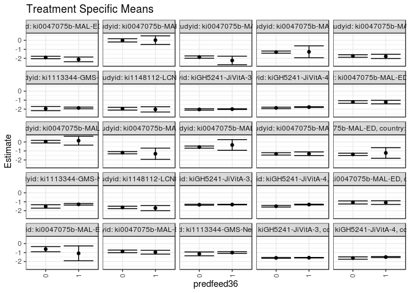

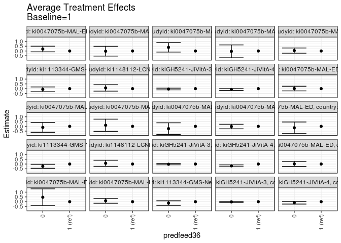

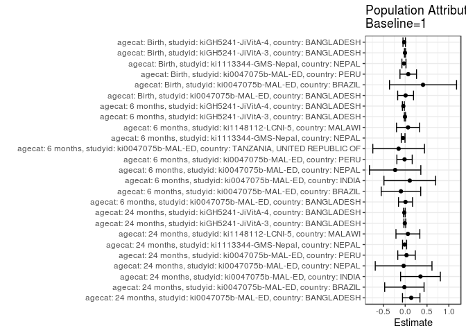

## Results Table

### Parameter: TSM

| agecat | studyid | country | intervention_level | baseline_level | estimate | ci_lower | ci_upper |
| --- | --- | --- | --- | --- | --- | --- | --- |
| Birth | ki0047075b-MAL-ED | BANGLADESH | 1 | NA | -1.0902778 | -1.2963722 | -0.8841833 |
| Birth | ki0047075b-MAL-ED | BANGLADESH | 0 | NA | -1.0753691 | -1.2489149 | -0.9018234 |
| Birth | ki0047075b-MAL-ED | BRAZIL | 1 | NA | -1.0850000 | -1.9106873 | -0.2593127 |
| Birth | ki0047075b-MAL-ED | BRAZIL | 0 | NA | -0.6185965 | -0.9082545 | -0.3289385 |
| Birth | ki0047075b-MAL-ED | PERU | 1 | NA | -0.9617241 | -1.1730583 | -0.7503900 |
| Birth | ki0047075b-MAL-ED | PERU | 0 | NA | -0.8665455 | -1.0109497 | -0.7221412 |
| Birth | ki1113344-GMS-Nepal | NEPAL | 1 | NA | -1.0018009 | -1.0995626 | -0.9040393 |
| Birth | ki1113344-GMS-Nepal | NEPAL | 0 | NA | -1.1442308 | -1.3584754 | -0.9299861 |
| Birth | kiGH5241-JiVitA-3 | BANGLADESH | 1 | NA | -1.5721250 | -1.6009738 | -1.5432763 |
| Birth | kiGH5241-JiVitA-3 | BANGLADESH | 0 | NA | -1.5909885 | -1.6428750 | -1.5391020 |
| Birth | kiGH5241-JiVitA-4 | BANGLADESH | 1 | NA | -1.5014207 | -1.5542959 | -1.4485455 |
| Birth | kiGH5241-JiVitA-4 | BANGLADESH | 0 | NA | -1.6085714 | -1.7381841 | -1.4789588 |
| 6 months | ki0047075b-MAL-ED | BANGLADESH | 1 | NA | -1.2147119 | -1.4071525 | -1.0222714 |
| 6 months | ki0047075b-MAL-ED | BANGLADESH | 0 | NA | -1.2034696 | -1.3514932 | -1.0554460 |
| 6 months | ki0047075b-MAL-ED | BRAZIL | 1 | NA | 0.1442000 | -0.3475370 | 0.6359370 |
| 6 months | ki0047075b-MAL-ED | BRAZIL | 0 | NA | 0.0344475 | -0.1146572 | 0.1835521 |
| 6 months | ki0047075b-MAL-ED | INDIA | 1 | NA | -1.3111765 | -1.9381796 | -0.6841733 |
| 6 months | ki0047075b-MAL-ED | INDIA | 0 | NA | -1.1972685 | -1.3162734 | -1.0782637 |
| 6 months | ki0047075b-MAL-ED | NEPAL | 1 | NA | -0.3325000 | -0.9301243 | 0.2651243 |
| 6 months | ki0047075b-MAL-ED | NEPAL | 0 | NA | -0.5702349 | -0.6852437 | -0.4552262 |
| 6 months | ki0047075b-MAL-ED | PERU | 1 | NA | -1.3087037 | -1.5103370 | -1.1070704 |
| 6 months | ki0047075b-MAL-ED | PERU | 0 | NA | -1.3282708 | -1.4565839 | -1.1999578 |
| 6 months | ki0047075b-MAL-ED | TANZANIA, UNITED REPUBLIC OF | 1 | NA | -1.2240000 | -1.8175386 | -0.6304614 |
| 6 months | ki0047075b-MAL-ED | TANZANIA, UNITED REPUBLIC OF | 0 | NA | -1.3768487 | -1.5024066 | -1.2512909 |
| 6 months | ki1113344-GMS-Nepal | NEPAL | 1 | NA | -1.2868918 | -1.3738868 | -1.1998968 |
| 6 months | ki1113344-GMS-Nepal | NEPAL | 0 | NA | -1.5221429 | -1.7134970 | -1.3307887 |
| 6 months | ki1148112-LCNI-5 | MALAWI | 1 | NA | -1.7051064 | -1.9955729 | -1.4146399 |
| 6 months | ki1148112-LCNI-5 | MALAWI | 0 | NA | -1.6259111 | -1.7571663 | -1.4946560 |
| 6 months | kiGH5241-JiVitA-3 | BANGLADESH | 1 | NA | -1.3103792 | -1.3423759 | -1.2783825 |
| 6 months | kiGH5241-JiVitA-3 | BANGLADESH | 0 | NA | -1.3318530 | -1.3867621 | -1.2769438 |
| 6 months | kiGH5241-JiVitA-4 | BANGLADESH | 1 | NA | -1.3095466 | -1.3507435 | -1.2683497 |
| 6 months | kiGH5241-JiVitA-4 | BANGLADESH | 0 | NA | -1.4978809 | -1.5900146 | -1.4057472 |
| 24 months | ki0047075b-MAL-ED | BANGLADESH | 1 | NA | -2.1169565 | -2.3783862 | -1.8555269 |
| 24 months | ki0047075b-MAL-ED | BANGLADESH | 0 | NA | -1.9115385 | -2.0492229 | -1.7738540 |
| 24 months | ki0047075b-MAL-ED | BRAZIL | 1 | NA | 0.0245000 | -0.4541432 | 0.5031432 |
| 24 months | ki0047075b-MAL-ED | BRAZIL | 0 | NA | 0.0036465 | -0.1765847 | 0.1838778 |
| 24 months | ki0047075b-MAL-ED | INDIA | 1 | NA | -2.2405882 | -2.7153892 | -1.7657873 |
| 24 months | ki0047075b-MAL-ED | INDIA | 0 | NA | -1.8618841 | -1.9917210 | -1.7320472 |
| 24 months | ki0047075b-MAL-ED | NEPAL | 1 | NA | -1.2725000 | -1.9347673 | -0.6102327 |
| 24 months | ki0047075b-MAL-ED | NEPAL | 0 | NA | -1.3095434 | -1.4315531 | -1.1875337 |
| 24 months | ki0047075b-MAL-ED | PERU | 1 | NA | -1.7833019 | -2.0156626 | -1.5509412 |
| 24 months | ki0047075b-MAL-ED | PERU | 0 | NA | -1.7414302 | -1.8833645 | -1.5994958 |
| 24 months | ki1113344-GMS-Nepal | NEPAL | 1 | NA | -1.8696786 | -1.9637288 | -1.7756284 |
| 24 months | ki1113344-GMS-Nepal | NEPAL | 0 | NA | -1.9416466 | -2.1743549 | -1.7089382 |
| 24 months | ki1148112-LCNI-5 | MALAWI | 1 | NA | -2.0273529 | -2.3204751 | -1.7342307 |
| 24 months | ki1148112-LCNI-5 | MALAWI | 0 | NA | -1.9514839 | -2.1097913 | -1.7931764 |
| 24 months | kiGH5241-JiVitA-3 | BANGLADESH | 1 | NA | -1.9989562 | -2.0417975 | -1.9561149 |
| 24 months | kiGH5241-JiVitA-3 | BANGLADESH | 0 | NA | -2.0346800 | -2.1142814 | -1.9550786 |
| 24 months | kiGH5241-JiVitA-4 | BANGLADESH | 1 | NA | -1.7721128 | -1.8153418 | -1.7288838 |
| 24 months | kiGH5241-JiVitA-4 | BANGLADESH | 0 | NA | -1.8636771 | -1.9455194 | -1.7818349 |

### Parameter: E(Y)

| agecat | studyid | country | intervention_level | baseline_level | estimate | ci_lower | ci_upper |
| --- | --- | --- | --- | --- | --- | --- | --- |
| Birth | ki0047075b-MAL-ED | BANGLADESH | NA | NA | -1.0802262 | -1.2151319 | -0.9453206 |
| Birth | ki0047075b-MAL-ED | BRAZIL | NA | NA | -0.6760000 | -0.9521457 | -0.3998543 |
| Birth | ki0047075b-MAL-ED | PERU | NA | NA | -0.8913004 | -1.0115814 | -0.7710195 |
| Birth | ki1113344-GMS-Nepal | NEPAL | NA | NA | -1.0299620 | -1.1192344 | -0.9406896 |
| Birth | kiGH5241-JiVitA-3 | BANGLADESH | NA | NA | -1.5762700 | -1.6018685 | -1.5506716 |
| Birth | kiGH5241-JiVitA-4 | BANGLADESH | NA | NA | -1.5234724 | -1.5733491 | -1.4735957 |
| 6 months | ki0047075b-MAL-ED | BANGLADESH | NA | NA | -1.2072639 | -1.3248889 | -1.0896388 |
| 6 months | ki0047075b-MAL-ED | BRAZIL | NA | NA | 0.0475758 | -0.0963508 | 0.1915023 |
| 6 months | ki0047075b-MAL-ED | INDIA | NA | NA | -1.2055794 | -1.3250712 | -1.0860876 |
| 6 months | ki0047075b-MAL-ED | NEPAL | NA | NA | -0.5621418 | -0.6752179 | -0.4490658 |
| 6 months | ki0047075b-MAL-ED | PERU | NA | NA | -1.3230913 | -1.4314947 | -1.2146879 |
| 6 months | ki0047075b-MAL-ED | TANZANIA, UNITED REPUBLIC OF | NA | NA | -1.3737037 | -1.4970489 | -1.2503585 |
| 6 months | ki1113344-GMS-Nepal | NEPAL | NA | NA | -1.3337634 | -1.4135810 | -1.2539459 |
| 6 months | ki1148112-LCNI-5 | MALAWI | NA | NA | -1.6395956 | -1.7592633 | -1.5199278 |
| 6 months | kiGH5241-JiVitA-3 | BANGLADESH | NA | NA | -1.3152982 | -1.3444394 | -1.2861570 |
| 6 months | kiGH5241-JiVitA-4 | BANGLADESH | NA | NA | -1.3514886 | -1.3904044 | -1.3125729 |
| 24 months | ki0047075b-MAL-ED | BANGLADESH | NA | NA | -1.9783962 | -2.1050210 | -1.8517715 |
| 24 months | ki0047075b-MAL-ED | BRAZIL | NA | NA | 0.0061144 | -0.1625850 | 0.1748138 |
| 24 months | ki0047075b-MAL-ED | INDIA | NA | NA | -1.8906250 | -2.0165920 | -1.7646580 |
| 24 months | ki0047075b-MAL-ED | NEPAL | NA | NA | -1.3082379 | -1.4282426 | -1.1882331 |
| 24 months | ki0047075b-MAL-ED | PERU | NA | NA | -1.7524710 | -1.8736426 | -1.6312994 |
| 24 months | ki1113344-GMS-Nepal | NEPAL | NA | NA | -1.8830717 | -1.9710591 | -1.7950844 |
| 24 months | ki1148112-LCNI-5 | MALAWI | NA | NA | -1.9651323 | -2.1053230 | -1.8249415 |
| 24 months | kiGH5241-JiVitA-3 | BANGLADESH | NA | NA | -2.0071989 | -2.0453355 | -1.9690623 |
| 24 months | kiGH5241-JiVitA-4 | BANGLADESH | NA | NA | -1.7922845 | -1.8313538 | -1.7532153 |

### Parameter: ATE

| agecat | studyid | country | intervention_level | baseline_level | estimate | ci_lower | ci_upper |
| --- | --- | --- | --- | --- | --- | --- | --- |
| Birth | ki0047075b-MAL-ED | BANGLADESH | 1 | 1 | 0.0000000 | 0.0000000 | 0.0000000 |
| Birth | ki0047075b-MAL-ED | BANGLADESH | 0 | 1 | 0.0149087 | -0.2545223 | 0.2843396 |
| Birth | ki0047075b-MAL-ED | BRAZIL | 1 | 1 | 0.0000000 | 0.0000000 | 0.0000000 |
| Birth | ki0047075b-MAL-ED | BRAZIL | 0 | 1 | 0.4664035 | -0.4086172 | 1.3414243 |
| Birth | ki0047075b-MAL-ED | PERU | 1 | 1 | 0.0000000 | 0.0000000 | 0.0000000 |
| Birth | ki0047075b-MAL-ED | PERU | 0 | 1 | 0.0951787 | -0.1607797 | 0.3511371 |
| Birth | ki1113344-GMS-Nepal | NEPAL | 1 | 1 | 0.0000000 | 0.0000000 | 0.0000000 |
| Birth | ki1113344-GMS-Nepal | NEPAL | 0 | 1 | -0.1424298 | -0.3779253 | 0.0930656 |
| Birth | kiGH5241-JiVitA-3 | BANGLADESH | 1 | 1 | 0.0000000 | 0.0000000 | 0.0000000 |
| Birth | kiGH5241-JiVitA-3 | BANGLADESH | 0 | 1 | -0.0188635 | -0.0773055 | 0.0395785 |
| Birth | kiGH5241-JiVitA-4 | BANGLADESH | 1 | 1 | 0.0000000 | 0.0000000 | 0.0000000 |
| Birth | kiGH5241-JiVitA-4 | BANGLADESH | 0 | 1 | -0.1071507 | -0.2463676 | 0.0320661 |
| 6 months | ki0047075b-MAL-ED | BANGLADESH | 1 | 1 | 0.0000000 | 0.0000000 | 0.0000000 |
| 6 months | ki0047075b-MAL-ED | BANGLADESH | 0 | 1 | 0.0112423 | -0.2315423 | 0.2540269 |
| 6 months | ki0047075b-MAL-ED | BRAZIL | 1 | 1 | 0.0000000 | 0.0000000 | 0.0000000 |
| 6 months | ki0047075b-MAL-ED | BRAZIL | 0 | 1 | -0.1097525 | -0.6235983 | 0.4040932 |
| 6 months | ki0047075b-MAL-ED | INDIA | 1 | 1 | 0.0000000 | 0.0000000 | 0.0000000 |
| 6 months | ki0047075b-MAL-ED | INDIA | 0 | 1 | 0.1139080 | -0.5242888 | 0.7521047 |
| 6 months | ki0047075b-MAL-ED | NEPAL | 1 | 1 | 0.0000000 | 0.0000000 | 0.0000000 |
| 6 months | ki0047075b-MAL-ED | NEPAL | 0 | 1 | -0.2377349 | -0.8463250 | 0.3708551 |
| 6 months | ki0047075b-MAL-ED | PERU | 1 | 1 | 0.0000000 | 0.0000000 | 0.0000000 |
| 6 months | ki0047075b-MAL-ED | PERU | 0 | 1 | -0.0195671 | -0.2585655 | 0.2194312 |
| 6 months | ki0047075b-MAL-ED | TANZANIA, UNITED REPUBLIC OF | 1 | 1 | 0.0000000 | 0.0000000 | 0.0000000 |
| 6 months | ki0047075b-MAL-ED | TANZANIA, UNITED REPUBLIC OF | 0 | 1 | -0.1528487 | -0.7595223 | 0.4538248 |
| 6 months | ki1113344-GMS-Nepal | NEPAL | 1 | 1 | 0.0000000 | 0.0000000 | 0.0000000 |
| 6 months | ki1113344-GMS-Nepal | NEPAL | 0 | 1 | -0.2352511 | -0.4454522 | -0.0250499 |
| 6 months | ki1148112-LCNI-5 | MALAWI | 1 | 1 | 0.0000000 | 0.0000000 | 0.0000000 |
| 6 months | ki1148112-LCNI-5 | MALAWI | 0 | 1 | 0.0791953 | -0.2395502 | 0.3979408 |
| 6 months | kiGH5241-JiVitA-3 | BANGLADESH | 1 | 1 | 0.0000000 | 0.0000000 | 0.0000000 |
| 6 months | kiGH5241-JiVitA-3 | BANGLADESH | 0 | 1 | -0.0214738 | -0.0812267 | 0.0382791 |
| 6 months | kiGH5241-JiVitA-4 | BANGLADESH | 1 | 1 | 0.0000000 | 0.0000000 | 0.0000000 |
| 6 months | kiGH5241-JiVitA-4 | BANGLADESH | 0 | 1 | -0.1883343 | -0.2873520 | -0.0893166 |
| 24 months | ki0047075b-MAL-ED | BANGLADESH | 1 | 1 | 0.0000000 | 0.0000000 | 0.0000000 |
| 24 months | ki0047075b-MAL-ED | BANGLADESH | 0 | 1 | 0.2054181 | -0.0900518 | 0.5008880 |
| 24 months | ki0047075b-MAL-ED | BRAZIL | 1 | 1 | 0.0000000 | 0.0000000 | 0.0000000 |
| 24 months | ki0047075b-MAL-ED | BRAZIL | 0 | 1 | -0.0208535 | -0.5323050 | 0.4905980 |
| 24 months | ki0047075b-MAL-ED | INDIA | 1 | 1 | 0.0000000 | 0.0000000 | 0.0000000 |
| 24 months | ki0047075b-MAL-ED | INDIA | 0 | 1 | 0.3787042 | -0.1135290 | 0.8709374 |
| 24 months | ki0047075b-MAL-ED | NEPAL | 1 | 1 | 0.0000000 | 0.0000000 | 0.0000000 |
| 24 months | ki0047075b-MAL-ED | NEPAL | 0 | 1 | -0.0370434 | -0.7104558 | 0.6363691 |
| 24 months | ki0047075b-MAL-ED | PERU | 1 | 1 | 0.0000000 | 0.0000000 | 0.0000000 |
| 24 months | ki0047075b-MAL-ED | PERU | 0 | 1 | 0.0418717 | -0.2304091 | 0.3141526 |
| 24 months | ki1113344-GMS-Nepal | NEPAL | 1 | 1 | 0.0000000 | 0.0000000 | 0.0000000 |
| 24 months | ki1113344-GMS-Nepal | NEPAL | 0 | 1 | -0.0719680 | -0.3229632 | 0.1790273 |
| 24 months | ki1148112-LCNI-5 | MALAWI | 1 | 1 | 0.0000000 | 0.0000000 | 0.0000000 |
| 24 months | ki1148112-LCNI-5 | MALAWI | 0 | 1 | 0.0758691 | -0.2572704 | 0.4090085 |
| 24 months | kiGH5241-JiVitA-3 | BANGLADESH | 1 | 1 | 0.0000000 | 0.0000000 | 0.0000000 |
| 24 months | kiGH5241-JiVitA-3 | BANGLADESH | 0 | 1 | -0.0357238 | -0.1250916 | 0.0536440 |
| 24 months | kiGH5241-JiVitA-4 | BANGLADESH | 1 | 1 | 0.0000000 | 0.0000000 | 0.0000000 |
| 24 months | kiGH5241-JiVitA-4 | BANGLADESH | 0 | 1 | -0.0915644 | -0.1819839 | -0.0011448 |

### Parameter: PAR

| agecat | studyid | country | intervention_level | baseline_level | estimate | ci_lower | ci_upper |
| --- | --- | --- | --- | --- | --- | --- | --- |
| Birth | ki0047075b-MAL-ED | BANGLADESH | 1 | NA | 0.0100515 | -0.1716034 | 0.1917064 |
| Birth | ki0047075b-MAL-ED | BRAZIL | 1 | NA | 0.4090000 | -0.3592436 | 1.1772436 |
| Birth | ki0047075b-MAL-ED | PERU | 1 | NA | 0.0704237 | -0.1190422 | 0.2598896 |
| Birth | ki1113344-GMS-Nepal | NEPAL | 1 | NA | -0.0281610 | -0.0749750 | 0.0186530 |
| Birth | kiGH5241-JiVitA-3 | BANGLADESH | 1 | NA | -0.0041450 | -0.0169760 | 0.0086861 |
| Birth | kiGH5241-JiVitA-4 | BANGLADESH | 1 | NA | -0.0220517 | -0.0504301 | 0.0063267 |
| 6 months | ki0047075b-MAL-ED | BANGLADESH | 1 | NA | 0.0074480 | -0.1533982 | 0.1682942 |
| 6 months | ki0047075b-MAL-ED | BRAZIL | 1 | NA | -0.0966242 | -0.5490311 | 0.3557826 |
| 6 months | ki0047075b-MAL-ED | INDIA | 1 | NA | 0.1055971 | -0.4860482 | 0.6972424 |
| 6 months | ki0047075b-MAL-ED | NEPAL | 1 | NA | -0.2296418 | -0.8175399 | 0.3582562 |
| 6 months | ki0047075b-MAL-ED | PERU | 1 | NA | -0.0143876 | -0.1901247 | 0.1613495 |
| 6 months | ki0047075b-MAL-ED | TANZANIA, UNITED REPUBLIC OF | 1 | NA | -0.1497037 | -0.7412167 | 0.4418093 |
| 6 months | ki1113344-GMS-Nepal | NEPAL | 1 | NA | -0.0468717 | -0.0895153 | -0.0042281 |
| 6 months | ki1148112-LCNI-5 | MALAWI | 1 | NA | 0.0655108 | -0.1981815 | 0.3292031 |
| 6 months | kiGH5241-JiVitA-3 | BANGLADESH | 1 | NA | -0.0049190 | -0.0185886 | 0.0087506 |
| 6 months | kiGH5241-JiVitA-4 | BANGLADESH | 1 | NA | -0.0419421 | -0.0637025 | -0.0201817 |
| 24 months | ki0047075b-MAL-ED | BANGLADESH | 1 | NA | 0.1385603 | -0.0611652 | 0.3382858 |
| 24 months | ki0047075b-MAL-ED | BRAZIL | 1 | NA | -0.0183856 | -0.4693114 | 0.4325402 |
| 24 months | ki0047075b-MAL-ED | INDIA | 1 | NA | 0.3499632 | -0.1051034 | 0.8050299 |
| 24 months | ki0047075b-MAL-ED | NEPAL | 1 | NA | -0.0357379 | -0.6854184 | 0.6139426 |
| 24 months | ki0047075b-MAL-ED | PERU | 1 | NA | 0.0308309 | -0.1696708 | 0.2313326 |
| 24 months | ki1113344-GMS-Nepal | NEPAL | 1 | NA | -0.0133931 | -0.0601755 | 0.0333892 |
| 24 months | ki1148112-LCNI-5 | MALAWI | 1 | NA | 0.0622207 | -0.2110207 | 0.3354620 |
| 24 months | kiGH5241-JiVitA-3 | BANGLADESH | 1 | NA | -0.0082427 | -0.0288256 | 0.0123402 |
| 24 months | kiGH5241-JiVitA-4 | BANGLADESH | 1 | NA | -0.0201717 | -0.0399116 | -0.0004319 |